# Reglas de Asociación

Enrique Rocho Simon

Enero 2023

# 1 Introducción

## 1.1 Descripción de la PEC a realizar

La prueba está estructurada en un total de 8 ejercicios prácticos. Es necesario hacerlos todos para obtener una valoración máxima.

## 1.2 Criterios de valoración

| Pregunta | Criterio de valoración | Peso |
| --- | --- | --- |
| 1 | Se responde razonadamente a la pregunta realizada | 5% |
| 2 | Se explican los distintos métodos que acepta la función | 5% |
| 2 | Se aplican los métodos y se muestran los resultados | 10% |
| 3 | Se listan las reglas solicitadas y se comenta su implicación | 10% |
| 3 | Se genera y se comenta el gráfico solicitado | 5% |
| 3 | Se genera y se comenta el gráfico solicitado | 5% |
| 4 | Se explica para que sirve la función coverage() | 5% |
| 4 | Se listan las reglas solicitadas y se contesta la cuestion | 10% |
| 4 | Se genera y se comenta el gráfico solicitado | 10% |
| 5 | Se generan y se muestran los sets solicitados | 5% |
| 5 | Se listan las reglas solicitadas | 10% |
| 6 | Se explica el significado de los 3 conceptos solicitados | 5% |
| 7 | Se muestran las reglas solicitadas en cada caso y se comentan los resultados | 10% |
| 8 | Se plasma a través de una redacción extensa el conocimiento obtenido a partir de las reglas generadas | 5% |

## 1.3 Formato y fecha de entega

El formato de entrega es: studentname-PECn.html  
Fecha de Entrega: 29/01/2023  
Se debe entregar la PEC en el buzón de entregas del aula

# 2 Información técnica de la PEC

A continuación, se ofrece información técnica sobre el entorno en el que se ha generado este documento

```r
# Encoding utilizado: UTF-8

# Datos de sistema operativo y versión R
version
```

```
##                _
## platform       x86_64-w64-mingw32
## arch           x86_64
## os             mingw32
## system         x86_64, mingw32
## status
## major          4
## minor          1.2
## year           2021
## month          11
## day            01
## svn rev        81115
## language       R
## version.string R version 4.1.2 (2021-11-01)
## nickname       Bird Hippie
```

```r
# Versión de los paquetes utilizados:
# Paquete arules
packageVersion("arules")
```

```
## [1] '1.7.5'
```

```r
# Paquete arulesViz
packageVersion("arulesViz")
```

```
## [1] '1.5.1'
```

# 3 Base teórica

Para realizar la práctica se recomienda la lectura del punto 3.4 del material didáctico. Este punto se centra en la búsqueda de asociaciones, las cuales en nuestro caso se darán entre las características de la población adulta de USA.

El algoritmo **apriori** fue diseñado para la búsqueda de asociaciones entre los productos que forman parte de la cesta de la compra en el supermercado, hipermercado o gran superficie. El objetivo era determinar qué productos eran causa de la compra de otros. Sin embargo, el algoritmo **apriori** puede generalizarse para la búsqueda de asociaciones entre cualquier conjunto de items.

En esta PEC el objetivo será buscar asociaciones y relaciones entre algunas de las características de la población adulta de USA. Se han identificado una serie de características de la misma y se quiere averiguar si existen relaciones entre ellas.

Para ello utilizaremos el paquete **R** denominado **arules** del que podréis encontrar información extensa en el siguiente enlace https://cran.r-project.org/web/packages/arules/vignettes/arules.pdf

# 4 Descripción del problema

Vamos a analizar la relación entre las características que definen la población adulta de USA según las siguientes variables.

1. age
2. workclass
3. fnlwgt: final weight
4. education
5. education-num
6. marital-status
7. occupation
8. relationship
9. race
10. sex
11. capital-gain
12. capital-loss
13. hours-per-week
14. native-country
15. income

Podéis encontrar más información sobre el juego de datos en el siguiente enlace https://archive.ics.uci.edu/ml/datasets/adult

# 5 Cargar el juego de datos

El juego de datos forma parte de los ejemplos del paquete **arules**, por lo que una vez cargado el paquete simplemente tendremos que llamarlo. Para poder ser usado por algoritmos de búsqueda de asociaciones el juego de datos debe tener una estructura de transacciones, en la que cada fila represente una transacción, por ejemplo, en una cesta de la compra diríamos que cada fila representa una compra.

En nuestro caso una transacción o fila del juego de datos representa un individuo de la población de USA.

La generación de reglas de asociación requiere que las características a estudiar sean categóricas y no continuas, por este motivo se deberá realizar un proceso de conversión de las variables continuas en categóricas, para ello nos apoyaremos en la función de **R** **cut()**.

```r
library(arules)
data("AdultUCI")

# Proceso de categorización de variables continuas
AdultC <- AdultUCI
AdultC$age <- cut(AdultUCI$age, c(15,25,30,35,45,55,65,100))
AdultC$workclass <- AdultUCI$workclass
AdultC$fnlwgt <- cut(AdultUCI$fnlwgt, c(12200,20000,50000,100000,500000,750000,1000000,1500000))
AdultC$education <- AdultUCI$education
AdultC$`education-num` <- cut(AdultUCI$`education-num`, c(1,5,10,15,20))
AdultC$`marital-status` <- AdultUCI$`marital-status`
AdultC$occupation <- AdultUCI$occupation
AdultC$relationship <- AdultUCI$relationship
AdultC$race <- AdultUCI$race
AdultC$sex <- AdultUCI$sex
AdultC$`capital-gain` <- cut(AdultUCI$`capital-gain`,c(0,15000,20000,30000,40000,50000,60000,80000,100000))
AdultC$`capital-loss` <- cut(AdultUCI$`capital-loss`, c(0,500,1000,2000,3000,4000,5000))
AdultC$`hours-per-week` <- cut(AdultUCI$`hours-per-week`, c(0,10,20,30,50,60,80,100))
AdultC$`native-country` <- AdultUCI$`native-country`
AdultC$income <- AdultUCI$income
```

# 6 Función arules()

En R el juego de datos debe estar en formato **transaction**. Si no lo está, deberemos usar comandos de **R** para proceder a su conversión.

Observamos que en el proceso de generación de reglas exigimos un soporte y una confianza mínimos.

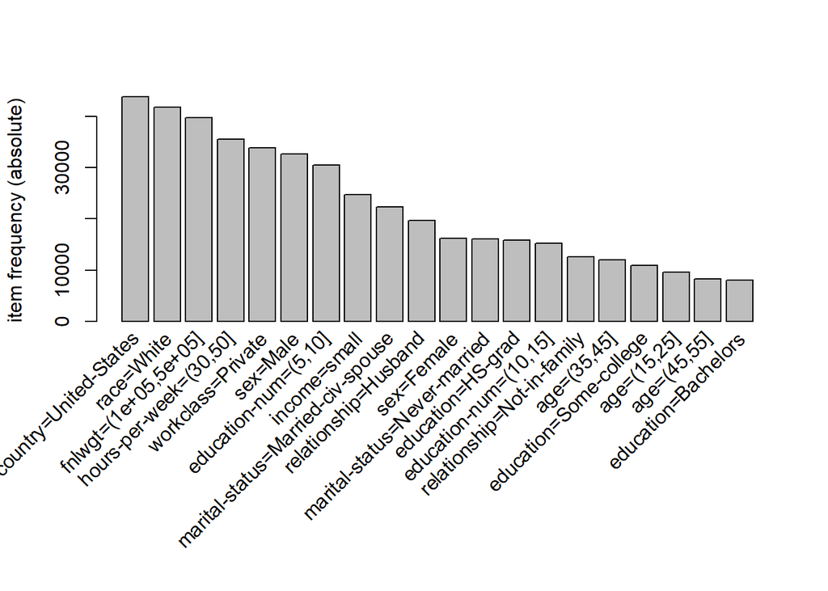

```r
# Conversión del juego de datos a formato transacción
Adult = as(AdultC, "transactions")

# Visualizamos un histograma de frecuencias
itemFrequencyPlot(Adult,topN=20,type="absolute")
```

```r
# Generación de reglas con soporte y confianza mínimos
rules = apriori(Adult, parameter=list(support=0.01, confidence=0.7, maxlen=7))
```

```
## Apriori
##
## Parameter specification:
##  confidence minval smax arem  aval originalSupport maxtime support minlen
##         0.7    0.1    1 none FALSE            TRUE       5    0.01      1
##  maxlen target  ext
##       7  rules TRUE
##
## Algorithmic control:
##  filter tree heap memopt load sort verbose
##     0.1 TRUE TRUE  FALSE TRUE    2    TRUE
##
## Absolute minimum support count: 488
##
## set item appearances ...[0 item(s)] done [0.00s].
## set transactions ...[138 item(s), 48842 transaction(s)] done [0.03s].
## sorting and recoding items ... [76 item(s)] done [0.01s].
## creating transaction tree ... done [0.02s].
## checking subsets of size 1 2 3 4 5 6 7
```

```
##  done [0.54s].
## writing ... [170708 rule(s)] done [0.03s].
## creating S4 object  ... done [0.07s].
```

```r
# Listado de reglas obtenidas
rules
```

```
## set of 170708 rules
```

Vemos como el número de reglas que se han formado superan las 170000, por ello es importante poder filtrar entre las reglas generadas, siendo tarea del analista identificar las más representativas o las que poseen información relevante.

## 6.1 Filtrado y selección de las reglas

Mostramos, a continuación, formas distintas de filtrado de reglas. En primer lugar, utilizamos el criterio “lift” y observamos como las reglas obtenidas aunque poseen un “lift” elevado son reglas triviales, que relacionan en nivel de educación con los años de estudio. Es evidente que tener un doctorado está relacionado con un número elevado de años de estudio. Alguna información se puede extraer de la tercera y cuarta regla con mayor elevación, que está en el hecho de ser de raza blanco se añade a la parte izquierda de la regla (antecedente) y aunque se reduce algo el soporte la confianza sigue siendo 1.

```r
# Listamos las 4 reglas con mayor lift
inspect(head(sort(rules, by="lift"),4));
```

```
##     lhs                         rhs                        support confidence   coverage     lift count
## [1] {education=Doctorate}    => {education-num=(15,20]} 0.01216166          1 0.01216166 82.22559   594
## [2] {education-num=(15,20]}  => {education=Doctorate}   0.01216166          1 0.01216166 82.22559   594
## [3] {education=Doctorate,
##      race=White}             => {education-num=(15,20]} 0.01076942          1 0.01076942 82.22559   526
## [4] {education-num=(15,20],
##      race=White}             => {education=Doctorate}   0.01076942          1 0.01076942 82.22559   526
```

Visualizamos ahora el resultado de la calidad de las reglas obtenido con la función `quality()`. Si nos fijamos en las 4 primeras reglas que se muestran, vemos que estas se corresponden con reglas con mucho soporte aunque con lift=1, lo que implicaría que dichas reglas no contienen información, simplemente están ligadas con características muy frecuentes en la muestra. Si inspeccionamos la regla con mayor elevación (lift=19.79814) vemos que el resultado vuelve a ser trivial.

```r
# Visualizamos la calidad de las reglas generadas
head(quality(rules))
```

```
##      support confidence   coverage      lift count
## 1 0.72798002  0.7279800 1.00000000  1.000000 35556
## 2 0.81364399  0.8136440 1.00000000  1.000000 39740
## 3 0.85504279  0.8550428 1.00000000  1.000000 41762
## 4 0.89742435  0.8974243 1.00000000  1.000000 43832
## 5 0.01042136  1.0000000 0.01042136 19.798135   509
## 6 0.01050326  0.9624765 0.01091274  2.100598   513
```

```r
# Inspeccionamos la regla con mayor lift entre las 6 que se muestran.
inspect(rules[quality(rules)$count==509][1])
```

```
##     lhs                    rhs                   support    confidence
## [1] {education=5th-6th} => {education-num=(1,5]} 0.01042136 1
##     coverage   lift     count
## [1] 0.01042136 19.79814 509
```

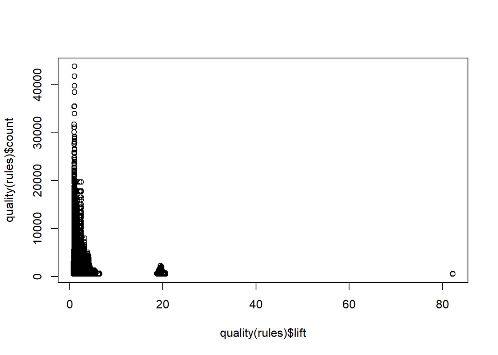

```r
# Generamos gráfico de frecuencias por elevación
plot(quality(rules)$lift,quality(rules)$count)
```

En general vemos como es difícil encontrar reglas que aporten conocimiento relevante. Una solución podría ser eliminar alguna de las variables con información redundante. Por ejemplo, eliminamos la variable educación numérica y volvemos a hacer el análisis anterior. En este caso observamos como la quinta regla con elevación superior a 2 ya contiene información no tan trivial, relacionando los ingresos con el estado cívil.

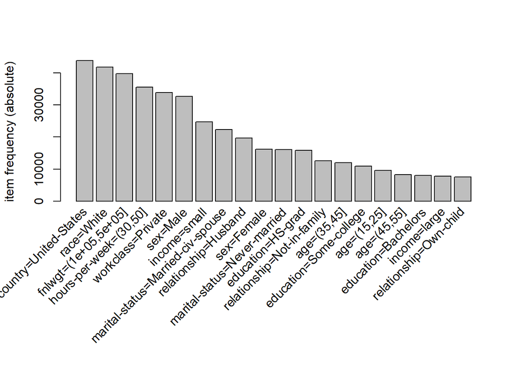

```r
AdultC2<-AdultC[,-5]
Adult2 = as(AdultC2, "transactions")

# Visualizamos un histograma de frecuencias
itemFrequencyPlot(Adult2,topN=20,type="absolute")
```

```r
# Generación de reglas con soporte y confianza mínimos
rules2 = apriori(Adult2, parameter=list(support=0.01, confidence=0.7, maxlen=7))
```

```
## Apriori
##
## Parameter specification:
##  confidence minval smax arem  aval originalSupport maxtime support minlen
##         0.7    0.1    1 none FALSE            TRUE       5    0.01      1
##  maxlen target  ext
##       7  rules TRUE
##
## Algorithmic control:
##  filter tree heap memopt load sort verbose
##     0.1 TRUE TRUE  FALSE TRUE    2    TRUE
##
## Absolute minimum support count: 488
##
## set item appearances ...[0 item(s)] done [0.00s].
## set transactions ...[134 item(s), 48842 transaction(s)] done [0.03s].
## sorting and recoding items ... [72 item(s)] done [0.01s].
## creating transaction tree ... done [0.02s].
## checking subsets of size 1 2 3 4 5 6 7
```

```
##  done [0.35s].
## writing ... [86922 rule(s)] done [0.01s].
## creating S4 object  ... done [0.04s].
```

```r
# Listado de reglas obtenidas
rules2
```

```
## set of 86922 rules
```

```r
head(quality(rules2))
```

```
##      support confidence   coverage     lift count
## 1 0.72798002  0.7279800 1.00000000 1.000000 35556
## 2 0.81364399  0.8136440 1.00000000 1.000000 39740
## 3 0.85504279  0.8550428 1.00000000 1.000000 41762
## 4 0.89742435  0.8974243 1.00000000 1.000000 43832
## 5 0.01050326  0.9624765 0.01091274 2.100598   513
## 6 0.01003235  0.9193246 0.01091274 1.075180   490
```

```r
# Inspeccionamos la regla con mayor lift entre las 6 que se muestran.
inspect(rules2[quality(rules2)$count==513][1])
```

```
##     lhs                               rhs                                    support confidence   coverage     lift count
## [1] {capital-gain=(1.5e+04,2e+04]} => {marital-status=Married-civ-spouse} 0.01050326  0.9624765 0.01091274 2.100598   513
```

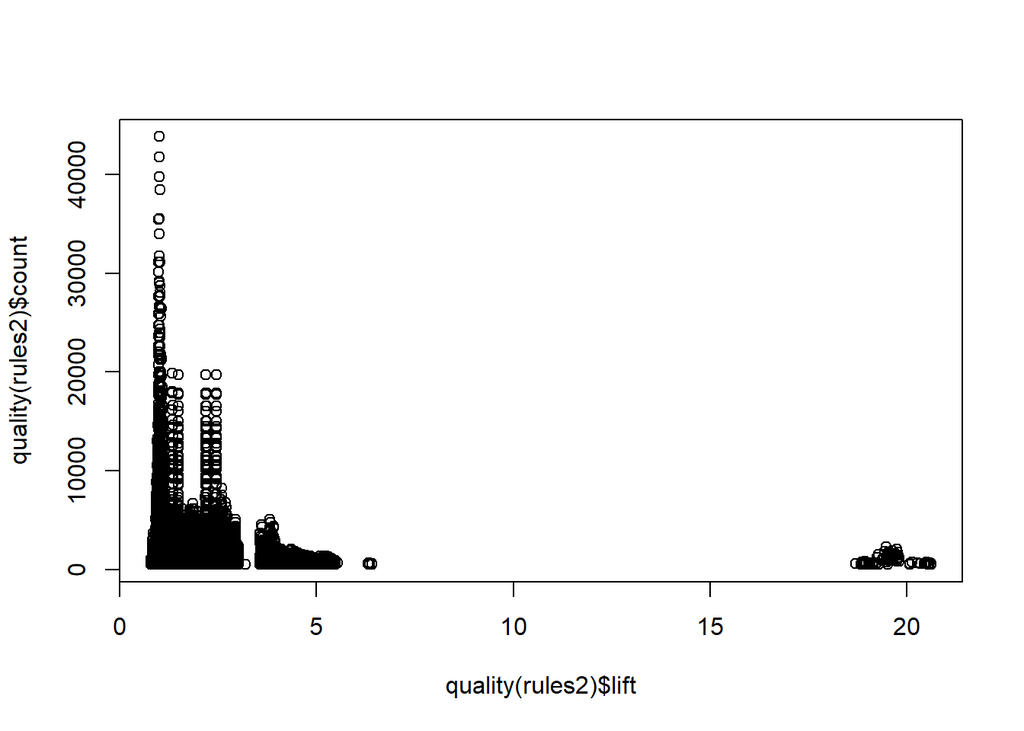

```r
# Generamos gráfico de frecuencias por elevación
plot(quality(rules2)$lift,quality(rules2)$count)
```

A continuación, volvemos a las reglas obtenidas con la base de datos original y mostramos más tecnicas de filtrado de reglas.

```r
# Extracción de reglas con una confianza superior a 0.8
subrules = rules[quality(rules)$confidence > 0.8]

subrules
```

```
## set of 131801 rules
```

Filtramos las 20 reglas con mayor elevación y posteriormente las listamos

```r
subrules2 = head(sort(rules, by="lift"), 20);

subrules2
```

```
## set of 20 rules
```

```r
inspect(subrules2)
```

```
##      lhs                                     rhs                        support confidence   coverage     lift count
## [1]  {education=Doctorate}                => {education-num=(15,20]} 0.01216166  1.0000000 0.01216166 82.22559   594
## [2]  {education-num=(15,20]}              => {education=Doctorate}   0.01216166  1.0000000 0.01216166 82.22559   594
## [3]  {education=Doctorate,
##       race=White}                         => {education-num=(15,20]} 0.01076942  1.0000000 0.01076942 82.22559   526
## [4]  {education-num=(15,20],
##       race=White}                         => {education=Doctorate}   0.01076942  1.0000000 0.01076942 82.22559   526
## [5]  {fnlwgt=(1e+05,5e+05],
##       marital-status=Married-civ-spouse,
##       race=White,
##       sex=Female,
##       native-country=United-States,
##       income=large}                       => {relationship=Wife}     0.01009377  0.9840319 0.01025757 20.61866   493
## [6]  {marital-status=Married-civ-spouse,
##       race=White,
##       sex=Female,
##       native-country=United-States,
##       income=large}                       => {relationship=Wife}     0.01238688  0.9837398 0.01259162 20.61254   605
## [7]  {marital-status=Married-civ-spouse,
##       sex=Female,
##       native-country=United-States,
##       income=large}                       => {relationship=Wife}     0.01359486  0.9822485 0.01384055 20.58129   664
## [8]  {marital-status=Married-civ-spouse,
##       race=White,
##       sex=Female,
##       income=large}                       => {relationship=Wife}     0.01328774  0.9818457 0.01353343 20.57285   649
## [9]  {fnlwgt=(1e+05,5e+05],
##       marital-status=Married-civ-spouse,
##       sex=Female,
##       native-country=United-States,
##       income=large}                       => {relationship=Wife}     0.01101511  0.9817518 0.01121985 20.57088   538
## [10] {fnlwgt=(1e+05,5e+05],
##       marital-status=Married-civ-spouse,
##       race=White,
##       sex=Female,
##       income=large}                       => {relationship=Wife}     0.01081037  0.9814126 0.01101511 20.56377   528
## [11] {marital-status=Married-civ-spouse,
##       sex=Female,
##       hours-per-week=(30,50],
##       native-country=United-States,
```

[output cut: 27 more lines]

```
##       native-country=United-States}       => {relationship=Wife}     0.01267352  0.9748031 0.01300111 20.42528   619
## [18] {education-num=(10,15],
##       marital-status=Married-civ-spouse,
##       race=White,
##       sex=Female,
##       native-country=United-States}       => {relationship=Wife}     0.01443430  0.9737569 0.01482331 20.40336   705
## [19] {education-num=(10,15],
##       marital-status=Married-civ-spouse,
##       sex=Female,
##       hours-per-week=(30,50],
##       native-country=United-States}       => {relationship=Wife}     0.01126080  0.9734513 0.01156791 20.39696   550
## [20] {education-num=(10,15],
##       marital-status=Married-civ-spouse,
##       sex=Female,
##       native-country=United-States}       => {relationship=Wife}     0.01611318  0.9716049 0.01658409 20.35827   787
```

```r
oneRule = sample(rules, 1);

inspect(oneRule);
```

```
##     lhs                               rhs                               support confidence   coverage     lift count
## [1] {age=(15,25],
##      workclass=Private,
##      education-num=(5,10],
##      occupation=Other-service,
##      native-country=United-States} => {marital-status=Never-married} 0.02383195  0.9187056 0.02594079 2.784105  1164
```

# 7 Visualizaciones de reglas

La forma más habitual de trabajar con reglas es listarlas en forma de tabla, que es lo que hemos hecho hasta ahora. A continuación, listamos la 10 primeras reglas del conjunto “rules” indicando algunas opciones de visualización. En el resultado se observan que las primeras 4 reglas no poseen antecedente, lo que implica que este no existe, y la consecuencia como tal ya cumple los criterios establecidos para la búsqueda de las reglas “(support=0.01, confidence=0.7, maxlen=7)”. El resto de las reglas tienen antecedente y, por ejemplo, la quinta regla ya la hemos comentado en la sección anterior.

```r
inspectRules <- inspect(rules[1:10], ruleSep = "--->", itemSep = " + ", setStart = "", setEnd ="", linebreak = FALSE)
```

```
##      lhs                               rhs
## [1]                               ---> hours-per-week=(30,50]
## [2]                               ---> fnlwgt=(1e+05,5e+05]
## [3]                               ---> race=White
## [4]                               ---> native-country=United-States
## [5]  education=5th-6th            ---> education-num=(1,5]
## [6]  capital-gain=(1.5e+04,2e+04] ---> marital-status=Married-civ-spouse
## [7]  capital-gain=(1.5e+04,2e+04] ---> race=White
## [8]  education=Doctorate          ---> education-num=(15,20]
## [9]  education-num=(15,20]        ---> education=Doctorate
## [10] education=Doctorate          ---> race=White
##      support    confidence coverage   lift      count
## [1]  0.72798002 0.7279800  1.00000000  1.000000 35556
## [2]  0.81364399 0.8136440  1.00000000  1.000000 39740
## [3]  0.85504279 0.8550428  1.00000000  1.000000 41762
## [4]  0.89742435 0.8974243  1.00000000  1.000000 43832
## [5]  0.01042136 1.0000000  0.01042136 19.798135   509
## [6]  0.01050326 0.9624765  0.01091274  2.100598   513
## [7]  0.01003235 0.9193246  0.01091274  1.075180   490
## [8]  0.01216166 1.0000000  0.01216166 82.225589   594
## [9]  0.01216166 1.0000000  0.01216166 82.225589   594
## [10] 0.01076942 0.8855219  0.01216166  1.035646   526
```

```r
knitr::kable(inspectRules)
```

|  | lhs |  | rhs | support | confidence | coverage | lift | count |
| --- | --- | --- | --- | --- | --- | --- | --- | --- |
| [1] |  | —> | hours-per-week=(30,50] | 0.7279800 | 0.7279800 | 1.0000000 | 1.000000 | 35556 |
| [2] |  | —> | fnlwgt=(1e+05,5e+05] | 0.8136440 | 0.8136440 | 1.0000000 | 1.000000 | 39740 |
| [3] |  | —> | race=White | 0.8550428 | 0.8550428 | 1.0000000 | 1.000000 | 41762 |
| [4] |  | —> | native-country=United-States | 0.8974243 | 0.8974243 | 1.0000000 | 1.000000 | 43832 |
| [5] | education=5th-6th | —> | education-num=(1,5] | 0.0104214 | 1.0000000 | 0.0104214 | 19.798135 | 509 |
| [6] | capital-gain=(1.5e+04,2e+04] | —> | marital-status=Married-civ-spouse | 0.0105033 | 0.9624765 | 0.0109127 | 2.100598 | 513 |
| [7] | capital-gain=(1.5e+04,2e+04] | —> | race=White | 0.0100323 | 0.9193246 | 0.0109127 | 1.075180 | 490 |
| [8] | education=Doctorate | —> | education-num=(15,20] | 0.0121617 | 1.0000000 | 0.0121617 | 82.225589 | 594 |
| [9] | education-num=(15,20] | —> | education=Doctorate | 0.0121617 | 1.0000000 | 0.0121617 | 82.225589 | 594 |
| [10] | education=Doctorate | —> | race=White | 0.0107694 | 0.8855219 | 0.0121617 | 1.035646 | 526 |

Sin embargo, existen técnicas más gráficas como los árboles de reglas que muestran como se relacionan los distintos items de las variables. Por ejemplo, en la siguiente gráfica se observa como desde el item “capital-gain=(1.5e+04,2e+04]” sale una flecha con dirección a “marital-status=Married-civ-spouse” y otra con dirección a “race=White”, lo que indica que estos dos últimos items comparten un mismo antecedente.

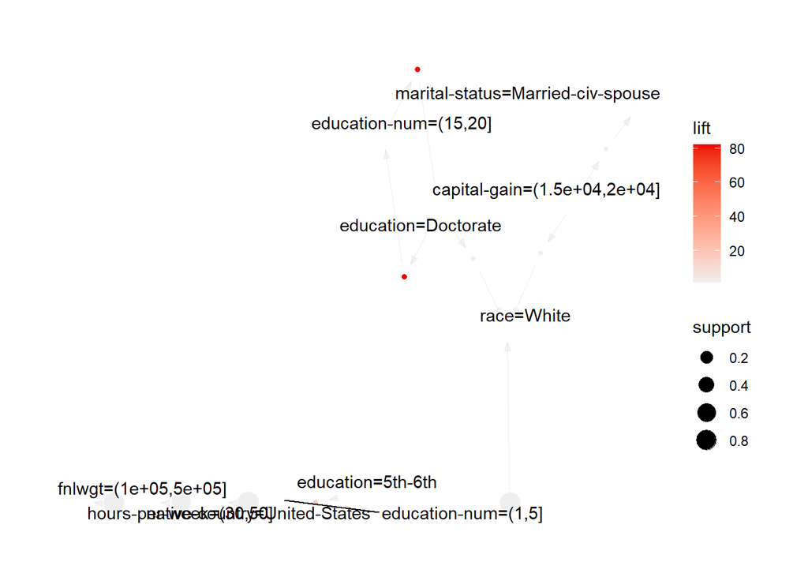

```r
library(arulesViz)
# Gráfico basado en árboles de reglas
plot(rules[1:10], method="graph")
```

Algunos gráficos de puntos o en forma de matriz también nos permiten analizar como se distribuyen los valores del soporte, la confianza o la elevación de las reglas.

```
## To reduce overplotting, jitter is added! Use jitter = 0 to prevent jitter.
```

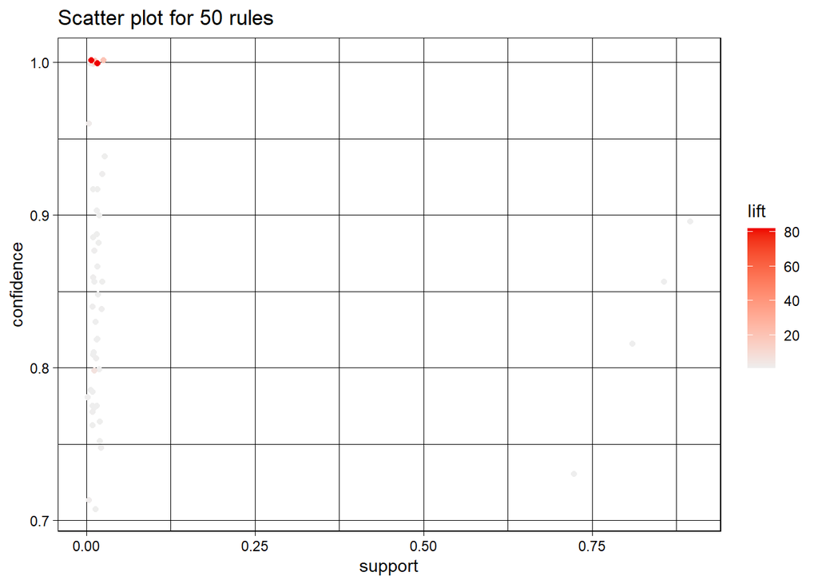

```r
# Gráfico de puntos
plot(rules[1:50], measure=c("support", "confidence"), shading="lift")
```

```
## To reduce overplotting, jitter is added! Use jitter = 0 to prevent jitter.
```

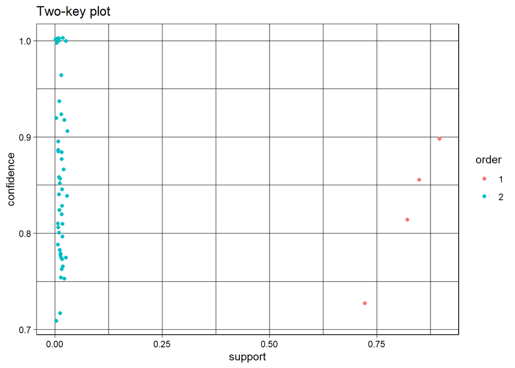

```r
plot(rules[1:50], shading="order", control=list(main = "Two-key plot"))
```

```
## Itemsets in Antecedent (LHS)
##  [1] "{education=Doctorate}"
##  [2] "{education-num=(15,20]}"
##  [3] "{education=5th-6th}"
##  [4] "{education=7th-8th}"
##  [5] "{education=9th}"
##  [6] "{education=Prof-school}"
##  [7] "{capital-gain=(1.5e+04,2e+04]}"
##  [8] "{hours-per-week=(60,80]}"
##  [9] "{native-country=Mexico}"
## [10] "{education=12th}"
## [11] "{occupation=Protective-serv}"
## [12] "{marital-status=Married-spouse-absent}"
## [13] "{}"
## [14] "{hours-per-week=(0,10]}"
## Itemsets in Consequent (RHS)
##  [1] "{native-country=United-States}"      "{race=White}"
##  [3] "{fnlwgt=(1e+05,5e+05]}"              "{hours-per-week=(30,50]}"
##  [5] "{workclass=Private}"                 "{sex=Male}"
##  [7] "{education-num=(5,10]}"              "{marital-status=Married-civ-spouse}"
##  [9] "{education-num=(10,15]}"             "{occupation=Prof-specialty}"
## [11] "{education-num=(1,5]}"               "{education=Doctorate}"
## [13] "{education-num=(15,20]}"
```

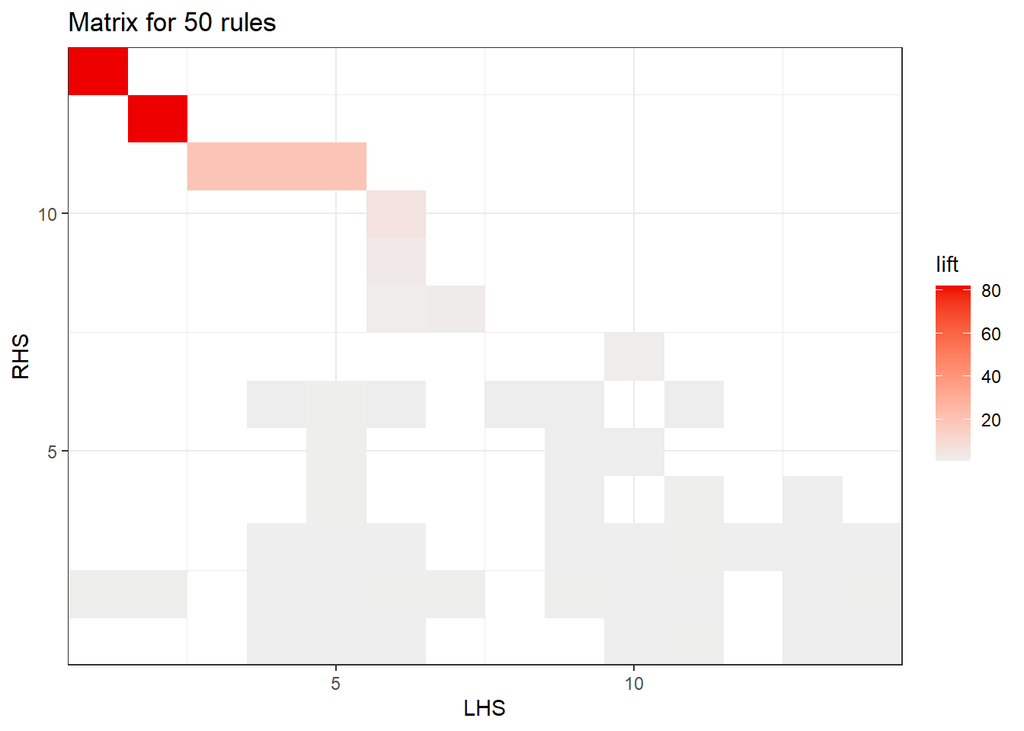

```r
# Comparando rhs con lhs
plot(rules[1:50], method="matrix", measure="lift")
```

# 8 Función eclat()

Una aproximación distinta puede ser usar la función **R** **eclat()** para identificar los valores más significativos de las distintas características. El objetivo es identificar los items o subconjuntos de items más frecuentes entre un conjunto de transacciones. También podemos identificar los subconjuntos de items según su número (1 item, 2 items…). Finalmente, al conjunto de combinaciones creados se añade una columna con la confianza de las reglas que podrían generarse con cada subconjunto de items.

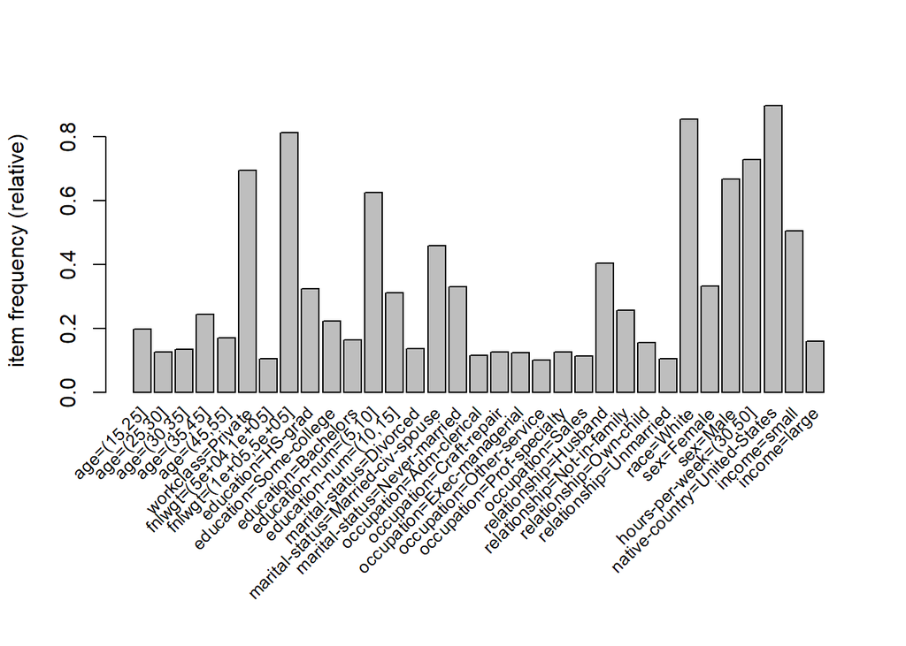

```r
itemFrequencyPlot(Adult, support = 0.1, cex.names=0.8)
```

```r
# Creamos sets o combinaciones de características según su relevancia.
fsets = eclat(Adult, parameter = list(support = 0.05), control = list(verbose=FALSE));

summary(fsets)
```

```
## set of 6270 itemsets
##
## most frequent items:
## native-country=United-States                   race=White
##                         2921                         2803
##         fnlwgt=(1e+05,5e+05]       hours-per-week=(30,50]
##                         2613                         2337
##            workclass=Private                      (Other)
##                         2304                        15412
##
## element (itemset/transaction) length distribution:sizes
##    1    2    3    4    5    6    7    8    9   10
##   45  331 1037 1733 1679  983  363   86   12    1
##
##    Min. 1st Qu.  Median    Mean 3rd Qu.    Max.
##   1.000   4.000   4.000   4.528   5.000  10.000
##
## summary of quality measures:
##     support            count
##  Min.   :0.05004   Min.   : 2444
##  1st Qu.:0.05923   1st Qu.: 2893
##  Median :0.07377   Median : 3603
##  Mean   :0.09725   Mean   : 4750
##  3rd Qu.:0.10431   3rd Qu.: 5095
##  Max.   :0.89742   Max.   :43832
##
## includes transaction ID lists: FALSE
##
## mining info:
##   data ntransactions support
##  Adult         48842    0.05
##                                                                                    call
##  eclat(data = Adult, parameter = list(support = 0.05), control = list(verbose = FALSE))
```

```r
# Seleccionamos los sets con un solo item o característica
singleItems = fsets[size(items(fsets)) == 1];
inspect(singleItems)
```

```
##      items                               support    count
## [1]  {native-country=United-States}      0.89742435 43832
## [2]  {race=White}                        0.85504279 41762
## [3]  {fnlwgt=(1e+05,5e+05]}              0.81364399 39740
## [4]  {hours-per-week=(30,50]}            0.72798002 35556
## [5]  {workclass=Private}                 0.69419762 33906
## [6]  {sex=Male}                          0.66848204 32650
## [7]  {education-num=(5,10]}              0.62487204 30520
## [8]  {income=small}                      0.50612178 24720
## [9]  {marital-status=Married-civ-spouse} 0.45819172 22379
## [10] {relationship=Husband}              0.40366897 19716
## [11] {sex=Female}                        0.33151796 16192
## [12] {marital-status=Never-married}      0.32998239 16117
## [13] {education=HS-grad}                 0.32316449 15784
## [14] {education-num=(10,15]}             0.31075714 15178
```

[output cut: 31 more lines]

```r
singleSupport = quality(singleItems)$support;

names(singleSupport) = unlist(LIST(items(singleItems), decode = FALSE));

head(singleSupport, n = 5);
```

```
##       136        74        19        94        11
## 0.8974243 0.8550428 0.8136440 0.7279800 0.6941976
```

```r
itemsetList = LIST(items(fsets), decode = FALSE);

itemsetList[1:6]
```

```
## [[1]]
## [1] 37 41
##
## [[2]]
## [1] 11 19 56
##
## [[3]]
## [1] 11 56 94
##
## [[4]]
## [1]  56 136
##
## [[5]]
## [1] 19 56
##
## [[6]]
## [1] 56 94
```

```r
# Determinamos la confianza de cada set
allConfidence = quality(fsets)$support / sapply(itemsetList, function(x) max(singleSupport[as.character(x)]));

quality(fsets) = cbind(quality(fsets), allConfidence);

summary(fsets)
```

```
## set of 6270 itemsets
##
## most frequent items:
## native-country=United-States                   race=White
##                         2921                         2803
##         fnlwgt=(1e+05,5e+05]       hours-per-week=(30,50]
##                         2613                         2337
##            workclass=Private                      (Other)
##                         2304                        15412
##
## element (itemset/transaction) length distribution:sizes
##    1    2    3    4    5    6    7    8    9   10
##   45  331 1037 1733 1679  983  363   86   12    1
##
##    Min. 1st Qu.  Median    Mean 3rd Qu.    Max.
##   1.000   4.000   4.000   4.528   5.000  10.000
##
## summary of quality measures:
##     support            count       allConfidence
##  Min.   :0.05004   Min.   : 2444   Min.   :0.05576
##  1st Qu.:0.05923   1st Qu.: 2893   1st Qu.:0.07068
##  Median :0.07377   Median : 3603   Median :0.08900
##  Mean   :0.09725   Mean   : 4750   Mean   :0.12339
##  3rd Qu.:0.10431   3rd Qu.: 5095   3rd Qu.:0.12994
##  Max.   :0.89742   Max.   :43832   Max.   :1.00000
##
## includes transaction ID lists: FALSE
##
## mining info:
##   data ntransactions support
##  Adult         48842    0.05
##                                                                                    call
##  eclat(data = Adult, parameter = list(support = 0.05), control = list(verbose = FALSE))
```

# 9 Preguntas

## 9.1 Pregunta 1

Al inicio de la práctica, utlizando la función **cut()** se realiza una tarea de categorización o discretización de las variables continuas del juego de datos AdultUCI y se genera la base de datos AdultC. Si observáis algunos valores de la nueva base de datos AdultC son “NA”. Explicad a que se debe la aparición de estos “NA”.

### 9.1.1 Respuesta 1

```r
#Revisamos qué columna a la que se ha aplicado cut tiene NA:

sum(is.na(AdultC$age))
```

```
## [1] 0
```

```r
sum(is.na(AdultC$fnlwgt))
```

```
## [1] 0
```

```r
sum(is.na(AdultC$`education-num`))
```

```
## [1] 83
```

```r
sum(is.na(AdultC$`capital-gain`))
```

```
## [1] 44807
```

```r
sum(is.na(AdultC$`capital-loss`))
```

```
## [1] 46560
```

```r
sum(is.na(AdultC$`hours-per-week`))
```

```
## [1] 0
```

Las columnas que tienen NA son:

```r
#sum(is.na(AdultC$`education-num`))

#[1] 83

#sum(is.na(AdultC$`capital-gain`))

#[1] 44807

#sum(is.na(AdultC$`capital-loss`))

#[1] 46560
```

```r
#Revisaremos `education-num`
#¿Cuales son las filas con NA de `education-num`?

which(is.na(AdultC$`education-num` ))
```

```
##  [1]   225   933  2885  2947  3447  3593  4108  6434  6865  7071  7174  7895
## [13]  8081  8089  8097  8776 10311 11135 11361 11735 13249 15060 16498 16563
## [25] 18416 20441 21371 21389 21723 21795 22168 22532 22941 24176 24559 24699
## [37] 25101 25114 25228 25653 25944 26502 26607 27153 27240 28396 31799 32036
## [49] 32225 32360 32433 33341 33380 33591 33621 34051 34060 34926 35027 35599
## [61] 36102 36988 37191 37291 38357 39616 39869 40000 40047 40298 40335 42866
## [73] 43283 43339 43516 44018 44239 46130 46144 46715 48075 48216 48526
```

```r
#Vamos a revisar la fila 225, que es una de las que nos ha dado NA:
AdultC[225,]
```

```
##         age workclass        fnlwgt education education-num marital-status
## 225 (45,55] Local-gov (1e+05,5e+05] Preschool          <NA>  Never-married
##            occupation  relationship  race    sex capital-gain capital-loss
## 225 Machine-op-inspct Not-in-family White Female         <NA>         <NA>
##     hours-per-week native-country income
## 225        (30,50]  United-States  small
```

```r
#Revisamos cómo era antes de la categorización:
AdultUCI[225,]
```

```
##     age workclass fnlwgt education education-num marital-status
## 225  53 Local-gov 140359 Preschool             1  Never-married
##            occupation  relationship  race    sex capital-gain capital-loss
## 225 Machine-op-inspct Not-in-family White Female            0            0
##     hours-per-week native-country income
## 225             35  United-States  small
```

El valor anterior era 1. Parece que muchos de los valores que antes eran 1 ahora son NA. Esto se debe a la división que se ha elegido para los intervalos en cut:

```r
#AdultC$`education-num`<- cut(AdultUCI$`education-num`, c(1,5,10,15,20))
```

Para solucionarlo se podría usar, entre otras, la siguiente alternativa:

```r
#cut(AdultUCI$`education-num`, c(0,1,5,10,15,20,100))
```

## 9.2 Pregunta 2

Alternativamente a la función **cut()**, el paquete **arules** dispone de la función **discretize()** para proceder a realizar tareas de categorización de variables contínuas.

Explica 4 de los métodos de discretización acepta esta función y aplica cada método en la tabla AdultUCI para categorizar sus variables continuas.

**Atención!** El método “frequency” puede dar el siguiente error “Some breaks are not unique, use fewer breaks for the data”. Es normal, simplemente reducid el número de intervalos.

### 9.2.1 Respuesta 2

> Los métodos de discretización de esta función son:

#“interval”= amplitud de intervalo similar. Cada intervalo tiene la misma amplitud a partir de los datos de las variables, es decir, por ejemplo para AdultUCI$age:

```r
#[17,26.1) [26.1,35.2) [35.2,44.4) [44.4,53.5) [53.5,62.6) [62.6,71.8) [71.8,80.9) [80.9,90]
#Cada intervalo tiene una amplitud de 9.1
```

#“frequency”= misma frecuencia para los intervalos. Todos los intervalos de los grupos son seleccionados de manera que todos los grupos contienen la misma cantidad de valores numéricos. Los valores numéricos son asignados al grupo que representa el rango que cubre el valor numérico. Por ejemplo para AdultUCI$fnlwgt, tenemos una cantidad similar de datos para cada intervalo (puede haber variables que cumplan mejor este método que otras)

```r
#[1.23e+04,7.97e+04) [7.97e+04,1.18e+05) [1.18e+05,1.52e+05) [1.52e+05,1.78e+05) [1.78e+05,2.01e+05)
#               6106                6105                6105                6105                6103

#[2.01e+05,2.38e+05) [2.38e+05,3.08e+05) [3.08e+05,1.49e+06]
#               6107                6105                6106
```

#“cluster” (k-means clustering): intentará ajustar k-clusters para cada input y después asignar cada observación a un cluster.

#“fixed”: en este caso damos nosotros los valores de los intervalos, como en el caso de cut().

```r
summary(AdultUCI)
```

```
##       age                   workclass         fnlwgt
##  Min.   :17.00   Private         :33906   Min.   :  12285
##  1st Qu.:28.00   Self-emp-not-inc: 3862   1st Qu.: 117551
##  Median :37.00   Local-gov       : 3136   Median : 178145
##  Mean   :38.64   State-gov       : 1981   Mean   : 189664
##  3rd Qu.:48.00   Self-emp-inc    : 1695   3rd Qu.: 237642
##  Max.   :90.00   (Other)         : 1463   Max.   :1490400
##                  NA's            : 2799
##         education     education-num                 marital-status
##  HS-grad     :15784   Min.   : 1.00   Divorced             : 6633
##  Some-college:10878   1st Qu.: 9.00   Married-AF-spouse    :   37
##  Bachelors   : 8025   Median :10.00   Married-civ-spouse   :22379
##  Masters     : 2657   Mean   :10.08   Married-spouse-absent:  628
##  Assoc-voc   : 2061   3rd Qu.:12.00   Never-married        :16117
##  11th        : 1812   Max.   :16.00   Separated            : 1530
##  (Other)     : 7625                   Widowed              : 1518
##            occupation            relationship                   race
##  Prof-specialty : 6172   Husband       :19716   Amer-Indian-Eskimo:  470
##  Craft-repair   : 6112   Not-in-family :12583   Asian-Pac-Islander: 1519
##  Exec-managerial: 6086   Other-relative: 1506   Black             : 4685
##  Adm-clerical   : 5611   Own-child     : 7581   Other             :  406
##  Sales          : 5504   Unmarried     : 5125   White             :41762
##  (Other)        :16548   Wife          : 2331
##  NA's           : 2809
##      sex         capital-gain    capital-loss    hours-per-week
##  Female:16192   Min.   :    0   Min.   :   0.0   Min.   : 1.00
##  Male  :32650   1st Qu.:    0   1st Qu.:   0.0   1st Qu.:40.00
##                 Median :    0   Median :   0.0   Median :40.00
##                 Mean   : 1079   Mean   :  87.5   Mean   :40.42
##                 3rd Qu.:    0   3rd Qu.:   0.0   3rd Qu.:45.00
##                 Max.   :99999   Max.   :4356.0   Max.   :99.00
##
##        native-country    income
##  United-States:43832   small:24720
##  Mexico       :  951   large: 7841
##  Philippines  :  295   NA's :16281
##  Germany      :  206
##  Puerto-Rico  :  184
##  (Other)      : 2517
##  NA's         :  857
```

```r
head(AdultUCI)
```

```
##   age        workclass fnlwgt education education-num     marital-status
## 1  39        State-gov  77516 Bachelors            13      Never-married
## 2  50 Self-emp-not-inc  83311 Bachelors            13 Married-civ-spouse
## 3  38          Private 215646   HS-grad             9           Divorced
## 4  53          Private 234721      11th             7 Married-civ-spouse
## 5  28          Private 338409 Bachelors            13 Married-civ-spouse
## 6  37          Private 284582   Masters            14 Married-civ-spouse
##          occupation  relationship  race    sex capital-gain capital-loss
## 1      Adm-clerical Not-in-family White   Male         2174            0
## 2   Exec-managerial       Husband White   Male            0            0
## 3 Handlers-cleaners Not-in-family White   Male            0            0
## 4 Handlers-cleaners       Husband Black   Male            0            0
## 5    Prof-specialty          Wife Black Female            0            0
## 6   Exec-managerial          Wife White Female            0            0
##   hours-per-week native-country income
## 1             40  United-States  small
## 2             13  United-States  small
## 3             40  United-States  small
## 4             40  United-States  small
## 5             40           Cuba  small
## 6             40  United-States  small
```

> Vamos a aplicar los diferentes metodos de discretización sobre las variables continuas.

> MÉTODO INTERVAL:

```r
AdultInt <- AdultUCI


#age
AdultInt$age <- discretize(AdultUCI$age, method = "interval", breaks = 8)
head(AdultInt$age)
```

```
## [1] [35.2,44.4) [44.4,53.5) [35.2,44.4) [44.4,53.5) [26.1,35.2) [35.2,44.4)
## 8 Levels: [17,26.1) [26.1,35.2) [35.2,44.4) [44.4,53.5) ... [80.9,90]
```

```r
summary(AdultInt$age)
```

```
##   [17,26.1) [26.1,35.2) [35.2,44.4) [44.4,53.5) [53.5,62.6) [62.6,71.8)
##       10780       11566       10856        8158        4720        2012
## [71.8,80.9)   [80.9,90]
##         602         148
```

```r
#fnlwgt
AdultInt$fnlwgt <- discretize(AdultUCI$fnlwgt, method = "interval", breaks = 8)
head(AdultInt$fnlwgt)
```

```
## [1] [1.23e+04,1.97e+05) [1.23e+04,1.97e+05) [1.97e+05,3.82e+05)
## [4] [1.97e+05,3.82e+05) [1.97e+05,3.82e+05) [1.97e+05,3.82e+05)
## 8 Levels: [1.23e+04,1.97e+05) [1.97e+05,3.82e+05) ... [1.31e+06,1.49e+06]
```

```r
summary(AdultInt$fnlwgt)
```

```
## [1.23e+04,1.97e+05) [1.97e+05,3.82e+05) [3.82e+05,5.67e+05) [5.67e+05,7.51e+05)
##               29473               17004                2074                 227
## [7.51e+05,9.36e+05) [9.36e+05,1.12e+06) [1.12e+06,1.31e+06) [1.31e+06,1.49e+06]
##                  42                  12                   6                   4
```

```r
#`education-num`
AdultInt$`education-num` <- discretize(AdultUCI$`education-num`, method = "interval", breaks = 5)
head(AdultInt$`education-num`)
```

```
## [1] [13,16] [13,16] [7,10)  [7,10)  [13,16] [13,16]
## Levels: [1,4) [4,7) [7,10) [10,13) [13,16]
```

```r
summary(AdultInt$`education-num`)
```

```
##   [1,4)   [4,7)  [7,10) [10,13) [13,16]
##     839    3100   18253   14540   12110
```

```r
#`capital-gain`
AdultInt$`capital-gain` <- discretize(AdultUCI$`capital-gain`, method = "interval", breaks = 9)
head(AdultInt$`capital-gain`)
```

```
## [1] [0,1.11e+04) [0,1.11e+04) [0,1.11e+04) [0,1.11e+04) [0,1.11e+04)
## [6] [0,1.11e+04)
## 9 Levels: [0,1.11e+04) [1.11e+04,2.22e+04) ... [8.89e+04,1e+05]
```

```r
summary(AdultInt$`capital-gain`)
```

```
##        [0,1.11e+04) [1.11e+04,2.22e+04) [2.22e+04,3.33e+04) [3.33e+04,4.44e+04)
##               47799                 712                  78                   9
## [4.44e+04,5.56e+04) [5.56e+04,6.67e+04) [6.67e+04,7.78e+04) [7.78e+04,8.89e+04)
##                   0                   0                   0                   0
##    [8.89e+04,1e+05]
##                 244
```

```r
#`capital-loss`
AdultInt$`capital-loss` <- discretize(AdultUCI$`capital-loss`,method = "interval", breaks = 7)
head(AdultInt$`capital-loss`)
```

```
## [1] [0,622) [0,622) [0,622) [0,622) [0,622) [0,622)
## 7 Levels: [0,622) [622,1.24e+03) [1.24e+03,1.87e+03) ... [3.73e+03,4.36e+03]
```

```r
summary(AdultInt$`capital-loss`)
```

```
##             [0,622)      [622,1.24e+03) [1.24e+03,1.87e+03) [1.87e+03,2.49e+03)
##               46574                  46                 813                1346
## [2.49e+03,3.11e+03) [3.11e+03,3.73e+03) [3.73e+03,4.36e+03]
##                  50                   4                   9
```

```r
#`hours-per-week`
AdultInt$`hours-per-week` <- discretize(AdultUCI$`hours-per-week`,method = "interval", breaks = 8)
head(AdultInt$`hours-per-week`)
```

```
## [1] [37.8,50) [1,13.2)  [37.8,50) [37.8,50) [37.8,50) [37.8,50)
## 8 Levels: [1,13.2) [13.2,25.5) [25.5,37.8) [37.8,50) [50,62.2) ... [86.8,99]
```

```r
summary(AdultInt$`hours-per-week`)
```

```
##    [1,13.2) [13.2,25.5) [25.5,37.8)   [37.8,50)   [50,62.2) [62.2,74.5)
##        1420        4493        4997       28251        8032         989
## [74.5,86.8)   [86.8,99]
##         439         221
```

> MÉTODO FREQUENCY:

```r
AdultFre <- AdultUCI

#age
AdultFre$age <- discretize(AdultUCI$age, method = "frequency", breaks = 8)
head(AdultFre$age)
```

```
## [1] [37,42) [48,56) [37,42) [48,56) [28,32) [37,42)
## Levels: [17,23) [23,28) [28,32) [32,37) [37,42) [42,48) [48,56) [56,90]
```

```r
summary(AdultFre$age)
```

```
## [17,23) [23,28) [28,32) [32,37) [37,42) [42,48) [48,56) [56,90]
##    5897    6115    5106    6576    6172    6610    6118    6248
```

```r
#fnlwgt
AdultFre$fnlwgt <- discretize(AdultUCI$fnlwgt, method = "frequency", breaks = 8)
head(AdultFre$fnlwgt)
```

```
## [1] [1.23e+04,7.97e+04) [7.97e+04,1.18e+05) [2.01e+05,2.38e+05)
## [4] [2.01e+05,2.38e+05) [3.08e+05,1.49e+06] [2.38e+05,3.08e+05)
## 8 Levels: [1.23e+04,7.97e+04) [7.97e+04,1.18e+05) ... [3.08e+05,1.49e+06]
```

```r
summary(AdultFre$fnlwgt)
```

```
## [1.23e+04,7.97e+04) [7.97e+04,1.18e+05) [1.18e+05,1.52e+05) [1.52e+05,1.78e+05)
##                6106                6105                6105                6105
## [1.78e+05,2.01e+05) [2.01e+05,2.38e+05) [2.38e+05,3.08e+05) [3.08e+05,1.49e+06]
##                6103                6107                6105                6106
```

```r
#`education-num`
#Cambiamos el numero de breaks debido a error de "only unique breaks are used...":
AdultFre$`education-num` <- discretize(AdultUCI$`education-num`, method = "frequency", breaks = 4)
head(AdultFre$`education-num`)
```

```
## [1] [12,16] [12,16] [9,10)  [1,9)   [12,16] [12,16]
## Levels: [1,9) [9,10) [10,12) [12,16]
```

```r
summary(AdultFre$`education-num`)
```

```
##   [1,9)  [9,10) [10,12) [12,16]
##    6408   15784   12939   13711
```

```r
#`capital-gain`
#Siempre vamos a tener error de "only unique breaks are used..." aunque reduzcamos el número de breaks, y lo agrupara solo en 1 intervalo, por lo que dejaremos breaks = 1
AdultFre$`capital-gain` <- discretize(AdultUCI$`capital-gain`, method = "frequency", breaks = 1)
head(AdultFre$`capital-gain`)
```

```
## [1] [0,1e+05] [0,1e+05] [0,1e+05] [0,1e+05] [0,1e+05] [0,1e+05]
## Levels: [0,1e+05]
```

```r
summary(AdultFre$`capital-gain`)
```

```
## [0,1e+05]
##     48842
```

```r
#`capital-loss`
#Siempre vamos a tener error de "only unique breaks are used..." aunque reduzcamos el número de breaks, y lo agrupara solo en 1 intervalo, por lo que dejaremos breaks = 1
AdultFre$`capital-loss` <- discretize(AdultUCI$`capital-loss`,method = "frequency", breaks = 1)
head(AdultFre$`capital-loss`)
```

```
## [1] [0,4.36e+03] [0,4.36e+03] [0,4.36e+03] [0,4.36e+03] [0,4.36e+03]
## [6] [0,4.36e+03]
## Levels: [0,4.36e+03]
```

```r
summary(AdultFre$`capital-loss`)
```

```
## [0,4.36e+03]
##        48842
```

```r
#`hours-per-week`
#Siempre vamos a tener error de "only unique breaks are used..." aunque reduzcamos el número de breaks, y lo agrupara solo en 1 intervalo, por lo que dejaremos breaks = 1
AdultFre$`hours-per-week` <- discretize(AdultUCI$`hours-per-week`,method = "frequency", breaks = 1)
head(AdultFre$`hours-per-week`)
```

```
## [1] [1,99] [1,99] [1,99] [1,99] [1,99] [1,99]
## Levels: [1,99]
```

```r
summary(AdultFre$`hours-per-week`)
```

```
## [1,99]
##  48842
```

> MÉTODO CLUSTER:

```r
AdultClu <- AdultUCI

#age
AdultClu$age <- discretize(AdultUCI$age, method = "cluster", breaks = 8)
head(AdultClu$age)
```

```
## [1] [31.5,39.4) [47.3,55.2) [31.5,39.4) [47.3,55.2) [24,31.5)   [31.5,39.4)
## 8 Levels: [17,24) [24,31.5) [31.5,39.4) [39.4,47.3) ... [73.2,90]
```

```r
summary(AdultClu$age)
```

```
##     [17,24)   [24,31.5) [31.5,39.4) [39.4,47.3) [47.3,55.2) [55.2,63.3)
##        7226        9892       10326        9032        6118        3821
## [63.3,73.2)   [73.2,90]
##        1905         522
```

```r
#fnlwgt
AdultClu$fnlwgt <- discretize(AdultUCI$fnlwgt, method = "cluster", breaks = 8)
head(AdultClu$fnlwgt)
```

```
## [1] [1.23e+04,8.12e+04) [8.12e+04,1.42e+05) [1.95e+05,2.52e+05)
## [4] [1.95e+05,2.52e+05) [3.27e+05,4.31e+05) [2.52e+05,3.27e+05)
## 8 Levels: [1.23e+04,8.12e+04) [8.12e+04,1.42e+05) ... [6.45e+05,1.49e+06]
```

```r
summary(AdultClu$fnlwgt)
```

```
## [1.23e+04,8.12e+04) [8.12e+04,1.42e+05) [1.42e+05,1.95e+05) [1.95e+05,2.52e+05)
##                6231               10334               12373                9358
## [2.52e+05,3.27e+05) [3.27e+05,4.31e+05) [4.31e+05,6.45e+05) [6.45e+05,1.49e+06]
##                5568                3758                1066                 154
```

```r
#`education-num`
AdultClu$`education-num` <- discretize(AdultUCI$`education-num`, method = "cluster", breaks = 5)
head(AdultInt$`education-num`)
```

```
## [1] [13,16] [13,16] [7,10)  [7,10)  [13,16] [13,16]
## Levels: [1,4) [4,7) [7,10) [10,13) [13,16]
```

```r
summary(AdultInt$`education-num`)
```

```
##   [1,4)   [4,7)  [7,10) [10,13) [13,16]
##     839    3100   18253   14540   12110
```

```r
#`capital-gain`
AdultClu$`capital-gain` <- discretize(AdultUCI$`capital-gain`, method = "cluster", breaks = 9)
head(AdultClu$`capital-gain`)
```

```
## [1] [1.76e+03,2.72e+03) [0,614)             [0,614)
## [4] [0,614)             [0,614)             [0,614)
## 9 Levels: [0,614) [614,1.76e+03) [1.76e+03,2.72e+03) ... [5.83e+04,1e+05]
```

```r
summary(AdultClu$`capital-gain`)
```

```
##             [0,614)      [614,1.76e+03) [1.76e+03,2.72e+03) [2.72e+03,3.65e+03)
##               44872                 135                 375                 513
## [3.65e+03,4.61e+03) [4.61e+03,6.47e+03) [6.47e+03,1.22e+04) [1.22e+04,5.83e+04)
##                 355                 458                1095                 795
##    [5.83e+04,1e+05]
##                 244
```

```r
#`capital-loss`
AdultClu$`capital-loss` <- discretize(AdultUCI$`capital-loss`,method = "cluster", breaks = 7)
head(AdultClu$`capital-loss`)
```

```
## [1] [0,407) [0,407) [0,407) [0,407) [0,407) [0,407)
## 7 Levels: [0,407) [407,1.19e+03) [1.19e+03,1.71e+03) ... [2.99e+03,4.36e+03]
```

```r
summary(AdultClu$`capital-loss`)
```

```
##             [0,407)      [407,1.19e+03) [1.19e+03,1.71e+03) [1.71e+03,1.93e+03)
##               46571                  49                 532                 879
##  [1.93e+03,2.2e+03)  [2.2e+03,2.99e+03) [2.99e+03,4.36e+03]
##                 490                 303                  18
```

```r
#`hours-per-week`
AdultClu$`hours-per-week` <- discretize(AdultUCI$`hours-per-week`,method = "cluster", breaks = 8)
head(AdultClu$`hours-per-week`)
```

```
## [1] [32.7,46.6) [9.76,19.6) [32.7,46.6) [32.7,46.6) [32.7,46.6) [32.7,46.6)
## 8 Levels: [1,9.76) [9.76,19.6) [19.6,32.7) [32.7,46.6) ... [88.1,99]
```

```r
summary(AdultClu$`hours-per-week`)
```

```
##    [1,9.76) [9.76,19.6) [19.6,32.7) [32.7,46.6) [46.6,60.5) [60.5,73.7)
##         700        1891        5695       29984        8896        1013
## [73.7,88.1)   [88.1,99]
##         447         216
```

> MÉTODO FIXED:

```r
AdultFix <- AdultUCI

#age
AdultFix$age <- discretize(AdultUCI$age, method = "fixed", breaks = c(15,25,30,35,45,55,65,100))
head(AdultFix$age)
```

```
## [1] [35,45) [45,55) [35,45) [45,55) [25,30) [35,45)
## Levels: [15,25) [25,30) [30,35) [35,45) [45,55) [55,65) [65,100]
```

```r
summary(AdultFix$age)
```

```
##  [15,25)  [25,30)  [30,35)  [35,45)  [45,55)  [55,65) [65,100]
##     8432     6083     6494    12193     8771     4782     2087
```

```r
#fnlwgt
AdultFix$fnlwgt <- discretize(AdultUCI$fnlwgt, method = "fixed", breaks = c(12200,20000,50000,100000,500000,750000,1000000,1500000))
head(AdultFix$fnlwgt)
```

```
## [1] [5e+04,1e+05) [5e+04,1e+05) [1e+05,5e+05) [1e+05,5e+05) [1e+05,5e+05)
## [6] [1e+05,5e+05)
## 7 Levels: [1.22e+04,2e+04) [2e+04,5e+04) [5e+04,1e+05) ... [1e+06,1.5e+06]
```

```r
summary(AdultFix$fnlwgt)
```

```
## [1.22e+04,2e+04)    [2e+04,5e+04)    [5e+04,1e+05)    [1e+05,5e+05)
##               39             3368             5153            39740
##  [5e+05,7.5e+05)  [7.5e+05,1e+06)  [1e+06,1.5e+06]
##              476               48               18
```

```r
#`education-num`
AdultFix$`education-num` <- discretize(AdultUCI$`education-num`, method = "fixed", breaks = c(1,5,10,15,20))
head(AdultFix$`education-num`)
```

```
## [1] [10,15) [10,15) [5,10)  [5,10)  [10,15) [10,15)
## Levels: [1,5) [5,10) [10,15) [15,20]
```

```r
summary(AdultFix$`education-num`)
```

```
##   [1,5)  [5,10) [10,15) [15,20]
##    1794   20398   25222    1428
```

```r
#`capital-gain`
AdultFix$`capital-gain` <- discretize(AdultUCI$`capital-gain`, method = "fixed", breaks = c(0,15000,20000,30000,40000,50000,60000,80000,100000))
head(AdultFix$`capital-gain`)
```

```
## [1] [0,1.5e+04) [0,1.5e+04) [0,1.5e+04) [0,1.5e+04) [0,1.5e+04) [0,1.5e+04)
## 8 Levels: [0,1.5e+04) [1.5e+04,2e+04) [2e+04,3e+04) ... [8e+04,1e+05]
```

```r
summary(AdultFix$`capital-gain`)
```

```
##     [0,1.5e+04) [1.5e+04,2e+04)   [2e+04,3e+04)   [3e+04,4e+04)   [4e+04,5e+04)
##           47928             533             128               6               3
##   [5e+04,6e+04)   [6e+04,8e+04)   [8e+04,1e+05]
##               0               0             244
```

```r
#`capital-loss`
AdultFix$`capital-loss` <- discretize(AdultUCI$`capital-loss`,method = "fixed", breaks = c(0,500,1000,2000,3000,4000,5000))
head(AdultFix$`capital-loss`)
```

```
## [1] [0,500) [0,500) [0,500) [0,500) [0,500) [0,500)
## 6 Levels: [0,500) [500,1e+03) [1e+03,2e+03) [2e+03,3e+03) ... [4e+03,5e+03]
```

```r
summary(AdultFix$`capital-loss`)
```

```
##       [0,500)   [500,1e+03) [1e+03,2e+03) [2e+03,3e+03) [3e+03,4e+03)
##         46574            31          1746           473            15
## [4e+03,5e+03]
##             3
```

```r
#`hours-per-week`
AdultFix$`hours-per-week` <- discretize(AdultUCI$`hours-per-week`,method = "fixed", breaks = c(0,10,20,30,50,60,80,100))
head(AdultFix$`hours-per-week`)
```

```
## [1] [30,50) [10,20) [30,50) [30,50) [30,50) [30,50)
## Levels: [0,10) [10,20) [20,30) [30,50) [50,60) [60,80) [80,100]
```

```r
summary(AdultFix$`hours-per-week`)
```

```
##   [0,10)  [10,20)  [20,30)  [30,50)  [50,60)  [60,80) [80,100]
##      700     1891     3560    33010     5828     3325      528
```

## 9.3 Pregunta 3

1. Lista las 10 reglas del conjunto **rules** con mayor confianza y con soporte superior a 0.4. Comente en este caso si algunas de estas reglas no aportan información relevante.
2. Genere un gráfico de puntos que represente las 200 primeras reglas con más soporte. Los ejes del gráfico serán el soporte y la confianza.
3. Obtenga un gráfico en forma de árbol de reglas donde se representen las reglas seleccionadas en el punto 1 de esta misma pregunta. Realice una interpretación del gráfico obtenido en términos generales y con un ejemplo a modo ilustrativo.

### 9.3.1 Respuesta 3

```r
#1.Lista las 10 reglas del conjunto **rules** con mayor confianza y con soporte superior a 0.4. Comente en este caso si algunas de estas reglas no aportan información relevante.

#Primero hacemos subset de support mayor que 0.4
Conf04 = rules[quality(rules)$support > 0.4]
Conf04
```

```
## set of 117 rules
```

```r
#Ahora ordenamos las 10 reglas con más confianza
Top10conf= head(sort(Conf04, by="confidence"),10)
Top10conf
```

```
## set of 10 rules
```

#Efectivamente hay reglas que no aportan información relevante, como por ejemplo en la regla con más confianza, donde relationship=Husband y Sex= Male es redundante. #Las reglas 1 a 5 en general aportan poca información a pesar de tener más confianza y se refieren a los mismos datos.

```r
#2. Genere un gráfico de puntos que represente las 200 primeras reglas con más soporte. Los ejes del gráfico serán el soporte y la confianza.

#Creamos subset:
Top200sup = head(sort(rules, by="support"), 200);

inspect(head(Top200sup))
```

```
##     lhs                               rhs                            support
## [1] {}                             => {native-country=United-States} 0.8974243
## [2] {}                             => {race=White}                   0.8550428
## [3] {}                             => {fnlwgt=(1e+05,5e+05]}         0.8136440
## [4] {race=White}                   => {native-country=United-States} 0.7881127
## [5] {native-country=United-States} => {race=White}                   0.7881127
## [6] {}                             => {hours-per-week=(30,50]}       0.7279800
##     confidence coverage  lift     count
## [1] 0.8974243  1.0000000 1.000000 43832
## [2] 0.8550428  1.0000000 1.000000 41762
## [3] 0.8136440  1.0000000 1.000000 39740
## [4] 0.9217231  0.8550428 1.027076 38493
## [5] 0.8781940  0.8974243 1.027076 38493
## [6] 0.7279800  1.0000000 1.000000 35556
```

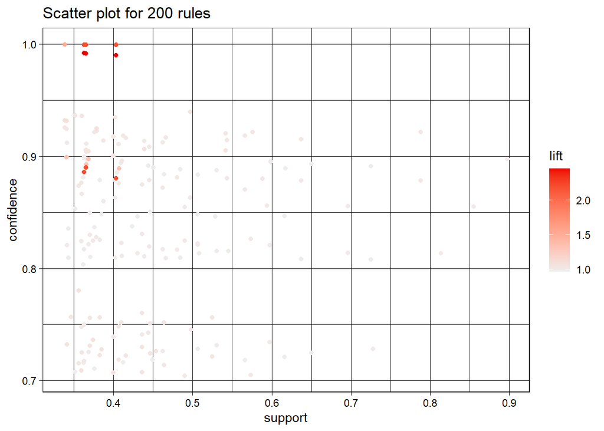

```r
#plot
library(arulesViz)

plot(Top200sup, method = "scatterplot", measure="support")
```

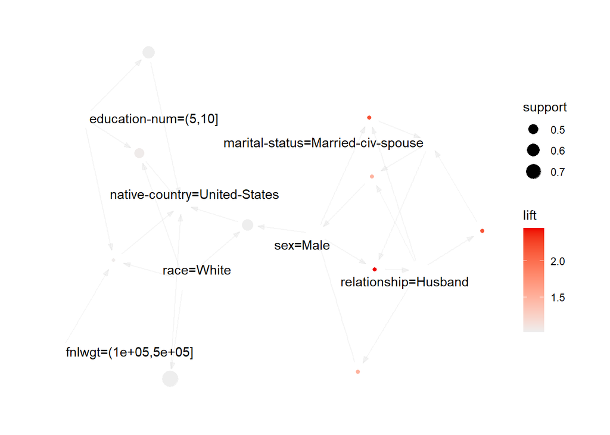

```r
#3.Obtenga un gráfico en forma de árbol de reglas donde se representen las reglas seleccionadas en el punto 1 de esta misma pregunta. Realice una interpretación del gráfico obtenido en términos generales y con un ejemplo a modo ilustrativo.

library(arulesViz)

# Gráfico basado en árboles de reglas

plot(Top10conf[1:10], method="graph")
```

Cada punto hace referencia a una de las 10 rules que hemos filtrado 10 con mayor confianza y soporte superior a 0.4. Los puntos más grandes hacen referencia a un mayor soporte y los más rojos a una mayor elevación. Las flechas que van desde una rule (punto) hasta un item (race, relationship…) son RHS, y al revés, flechas que van del item a la rule son LHS. En el caso de Sex=Male, hay flechas que se dirigen a native-country=United-States, a marital-status=Married-civ-spouse y a relationship=Husband, lo que implica que estos tres items comparten antecedente. Para race=White también tenemos flechas que van a native-country=United-States y fnlwtg=(1e+05,5e+05], por lo que estos últimos también comparten antecedente.

## 9.4 Pregunta 4

1. Investigad el funcionamiento de la función **coverage()** y aplicadlo al conjunto de reglas **rules**.
2. Lista las 15 reglas con **coverage** más bajo. Describa que implica la igualdad **coverage=support**.
3. Genera un gráfico de soporte por **coverage** y describa la relación existente entre ambos resultados.

### 9.4.1 Respuesta 4

```r
#1.Investigad el funcionamiento de la función **coverage()** y aplicadlo al conjunto de reglas **rules**.

#Representa la medida de cuanto a menudo se puede aplica una rule. Son la cantidad de instancias que se predicen correctamente.
#Se puede calcular a partir de las medidas de calidad de las rules (support y confianza). Si estos valores no están presentes, el soporte de LHS se calcula usando los datos proporcionados en transacciones.


quality(rules) <- cbind(quality(rules), coverage = coverage(rules))

inspect(head(rules))
```

```
##     lhs                               rhs                                    support confidence   coverage      lift count   coverage
## [1] {}                             => {hours-per-week=(30,50]}            0.72798002  0.7279800 1.00000000  1.000000 35556 1.00000000
## [2] {}                             => {fnlwgt=(1e+05,5e+05]}              0.81364399  0.8136440 1.00000000  1.000000 39740 1.00000000
## [3] {}                             => {race=White}                        0.85504279  0.8550428 1.00000000  1.000000 41762 1.00000000
## [4] {}                             => {native-country=United-States}      0.89742435  0.8974243 1.00000000  1.000000 43832 1.00000000
## [5] {education=5th-6th}            => {education-num=(1,5]}               0.01042136  1.0000000 0.01042136 19.798135   509 0.01042136
## [6] {capital-gain=(1.5e+04,2e+04]} => {marital-status=Married-civ-spouse} 0.01050326  0.9624765 0.01091274  2.100598   513 0.01091274
```

```r
#2. Lista las 15 reglas con **coverage** más bajo. Describa que implica la igualdad **coverage=support**.

Last15Cov = tail(sort(rules, by="coverage"), 15)
inspect(Last15Cov)
```

```
##      lhs                                     rhs                                    support confidence   coverage     lift count   coverage
## [1]  {age=(35,45],
##       education=HS-grad,
##       marital-status=Divorced,
##       native-country=United-States,
##       income=small}                       => {education-num=(5,10]}              0.01001188          1 0.01001188 1.600328   489 0.01001188
## [2]  {age=(15,25],
##       education-num=(5,10],
##       marital-status=Married-civ-spouse,
##       relationship=Husband,
##       race=White}                         => {sex=Male}                          0.01001188          1 0.01001188 1.495926   489 0.01001188
## [3]  {age=(15,25],
##       education-num=(5,10],
##       relationship=Husband,
##       race=White,
##       sex=Male}                           => {marital-status=Married-civ-spouse} 0.01001188          1 0.01001188 2.182493   489 0.01001188
## [4]  {education=HS-grad,
##       occupation=Machine-op-inspct,
##       race=White,
##       sex=Male,
##       hours-per-week=(30,50],
##       income=small}                       => {education-num=(5,10]}              0.01001188          1 0.01001188 1.600328   489 0.01001188
## [5]  {age=(25,30],
##       workclass=Private,
##       education=HS-grad,
##       marital-status=Married-civ-spouse,
##       race=White,
##       hours-per-week=(30,50]}             => {education-num=(5,10]}              0.01001188          1 0.01001188 1.600328   489 0.01001188
## [6]  {workclass=Private,
##       education=Bachelors,
##       occupation=Exec-managerial,
##       race=White,
##       native-country=United-States,
##       income=large}                       => {education-num=(10,15]}             0.01001188          1 0.01001188 3.217947   489 0.01001188
## [7]  {workclass=Private,
##       education-num=(10,15],
##       occupation=Prof-specialty,
##       relationship=Husband,
##       race=White,
##       income=large}                       => {marital-status=Married-civ-spouse} 0.01001188          1 0.01001188 2.182493   489 0.01001188
```

[output cut: 33 more lines]

```
##       relationship=Own-child,
##       sex=Male,
##       income=small}                       => {education-num=(5,10]}              0.01001188          1 0.01001188 1.600328   489 0.01001188
## [14] {age=(35,45],
##       education=Bachelors,
##       marital-status=Married-civ-spouse,
##       sex=Male,
##       hours-per-week=(30,50],
##       income=large}                       => {education-num=(10,15]}             0.01001188          1 0.01001188 3.217947   489 0.01001188
## [15] {age=(45,55],
##       workclass=Private,
##       fnlwgt=(1e+05,5e+05],
##       education=Some-college,
##       sex=Male,
##       native-country=United-States}       => {education-num=(5,10]}              0.01001188          1 0.01001188 1.600328   489 0.01001188
```

Respecto a la igualdad coverage=support, vemos que también implica que confidence es = 1. Las 15 reglas también tienen el mismo count (489). Coverage es también llamada LHS-support, es el soporte de la parte izquierda de la asociación. Representa la medida de cuanto a menudo la regla puede ser aplicada. Puede ser calculada mediante soporte y confianza.

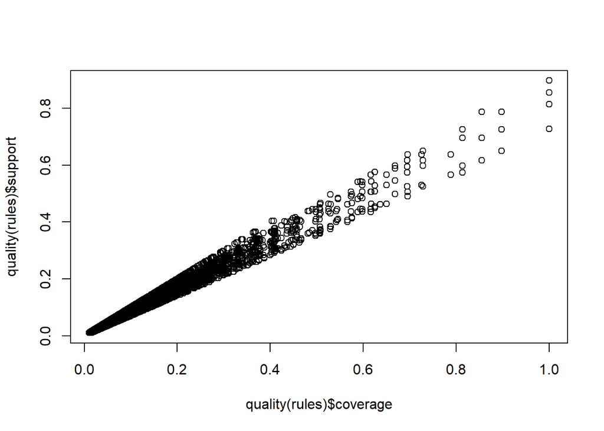

```r
#3.Genera un gráfico de soporte por **coverage** y describa la relación existente entre ambos resultados.

plot(quality(rules)$coverage,quality(rules)$support)
```

Coverage y support están muy relacionadas en cuanto a que un aumento de una supone un aumento de la otra en un valor muy similar además. Recordemos que Coverage puede ser calculada mediante las medidas de calidad de las reglas, soporte y confianza.

## 9.5 Pregunta 5

1. A partir del conjunto de reglas fsets generado con la función **eclat()** en el enunciado de la PEC, genera sets (conjuntos) de 3 items o caraterísticas (antecedentes).
2. A partir del set de 3 items generado, lista las 3 reglas con mayor soporte.

### 9.5.1 Respuesta 5

```r
#1.A partir del conjunto de reglas fsets generado con la función **eclat()** en el enunciado de la PEC, genera sets (conjuntos) de 3 items o caraterísticas (antecedentes).

# Seleccionamos sets de 3 características
ThreeItems = fsets[size(items(fsets)) == 3];
inspect(head(ThreeItems))
```

```
##     items                              support count allConfidence
## [1] {workclass=Private,
##      fnlwgt=(1e+05,5e+05],
##      occupation=Machine-op-inspct}  0.05053028  2468    0.06210367
## [2] {workclass=Private,
##      occupation=Machine-op-inspct,
##      hours-per-week=(30,50]}        0.05274149  2576    0.07244909
## [3] {fnlwgt=(1e+05,5e+05],
##      hours-per-week=(10,20],
##      native-country=United-States}  0.05003890  2444    0.05575835
## [4] {race=White,
##      hours-per-week=(10,20],
##      native-country=United-States}  0.05446132  2660    0.06068626
## [5] {race=White,
##      capital-gain=(0,1.5e+04],
##      native-country=United-States}  0.05282339  2580    0.05886111
## [6] {fnlwgt=(1e+05,5e+05],
##      hours-per-week=(20,30],
##      native-country=United-States}  0.05059170  2471    0.05637434
```

```r
#2. A partir del set de 3 items generado, lista las 3 reglas con mayor soporte.
inspect(head(sort(ThreeItems, by="support"),3))
```

```
##     items                            support count allConfidence
## [1] {fnlwgt=(1e+05,5e+05],
##      race=White,
##      native-country=United-States} 0.6370132 31113     0.7098239
## [2] {race=White,
##      hours-per-week=(30,50],
##      native-country=United-States} 0.5659473 27642     0.6306352
## [3] {workclass=Private,
##      race=White,
##      native-country=United-States} 0.5433848 26540     0.6054937
```

## 9.6 Pregunta 6

Selecciona una de las reglas generadas en algunas de las preguntas anteriores y comenta los valores de soporte, confianza y elevación que tiene asociados. ¿Qué significa cada uno de los 3 conceptos?

### 9.6.1 Respuesta 6

```r
# Por ejemplo, usamos el código del enunciado, donde se mencionaban las reglas con más elevación:

inspect(head(sort(rules, by="lift"),4))
```

```
##     lhs                         rhs                        support confidence   coverage     lift count   coverage
## [1] {education=Doctorate}    => {education-num=(15,20]} 0.01216166          1 0.01216166 82.22559   594 0.01216166
## [2] {education-num=(15,20]}  => {education=Doctorate}   0.01216166          1 0.01216166 82.22559   594 0.01216166
## [3] {education=Doctorate,
##      race=White}             => {education-num=(15,20]} 0.01076942          1 0.01076942 82.22559   526 0.01076942
## [4] {education-num=(15,20],
##      race=White}             => {education=Doctorate}   0.01076942          1 0.01076942 82.22559   526 0.01076942
```

En el caso de las 2 primeras líneas, tenemos un suporte de 0.01216166, confianza 1 y elevación 82.22559.

El soporte nos dice cúanto es de popular un grupo de items, medido en la proporción de transacciones en el que el grupo aparece. En este caso el soporte es del 1,216166 %. Normalmente se establece un márgen de soporte para reducir el número de reglas.

La confianza nos indica cómo de posible es que un item aparezca si se selecciona otro, expresado cómo {X -> Y} Se mide por la proporción de reglas con un item (X), en el que el otro item también aparece (Y). Puede ser interpretada como una estimación de la probabilidad. Es la probabilidad de encontrar rhs en la regla si también contiene lhs. En este caso la confianza es del 100%.

La elevación nos indica cómo es de probable que aparezca el item Y si aparece el item X, controlando cómo de populares son tanto X como Y. Si lift =1 significa que no hay asociación entre los items. Si el lift es >1, indica que hay propabilidad de que Y aparezca a la vez que X. Si el lift es <1, indica que hay poca propabilidad de que Y aparezca a la vez que X. En este ejemplo tenemos un lift de 82.22559, por lo que la probabilidad de que lhs y rhs aparezcan a la vez es alta.

## 9.7 Pregunta 7

Lista las 3 reglas con mayor soporte, las 4 con mayor confianza y las 6 con mayor elevación. Comenta si coinciden o no y describe sus principales características.

### 9.7.1 Respuesta 7

```r
#3 Con mayor soporte
inspect(head(sort(rules, by="support"),3))
```

```
##     lhs    rhs                            support   confidence coverage lift
## [1] {}  => {native-country=United-States} 0.8974243 0.8974243  1        1
## [2] {}  => {race=White}                   0.8550428 0.8550428  1        1
## [3] {}  => {fnlwgt=(1e+05,5e+05]}         0.8136440 0.8136440  1        1
##     count coverage
## [1] 43832 1
## [2] 41762 1
## [3] 39740 1
```

```r
#4 con mayor confianza
inspect(head(sort(rules, by="confidence"),4))
```

```
##     lhs                        rhs                     support    confidence
## [1] {education=5th-6th}     => {education-num=(1,5]}   0.01042136 1
## [2] {education=Doctorate}   => {education-num=(15,20]} 0.01216166 1
## [3] {education-num=(15,20]} => {education=Doctorate}   0.01216166 1
## [4] {education=12th}        => {education-num=(5,10]}  0.01345154 1
##     coverage   lift      count coverage
## [1] 0.01042136 19.798135 509   0.01042136
## [2] 0.01216166 82.225589 594   0.01216166
## [3] 0.01216166 82.225589 594   0.01216166
## [4] 0.01345154  1.600328 657   0.01345154
```

```r
#6 con mayor elevación
inspect(head(sort(rules, by="lift"),6))
```

```
##     lhs                                     rhs                        support confidence   coverage     lift count   coverage
## [1] {education=Doctorate}                => {education-num=(15,20]} 0.01216166  1.0000000 0.01216166 82.22559   594 0.01216166
## [2] {education-num=(15,20]}              => {education=Doctorate}   0.01216166  1.0000000 0.01216166 82.22559   594 0.01216166
## [3] {education=Doctorate,
##      race=White}                         => {education-num=(15,20]} 0.01076942  1.0000000 0.01076942 82.22559   526 0.01076942
## [4] {education-num=(15,20],
##      race=White}                         => {education=Doctorate}   0.01076942  1.0000000 0.01076942 82.22559   526 0.01076942
## [5] {fnlwgt=(1e+05,5e+05],
##      marital-status=Married-civ-spouse,
##      race=White,
##      sex=Female,
##      native-country=United-States,
##      income=large}                       => {relationship=Wife}     0.01009377  0.9840319 0.01025757 20.61866   493 0.01025757
## [6] {marital-status=Married-civ-spouse,
##      race=White,
##      sex=Female,
##      native-country=United-States,
##      income=large}                       => {relationship=Wife}     0.01238688  0.9837398 0.01259162 20.61254   605 0.01259162
```

No coinciden del todo, pero con excepciones.

## 9.8 Pregunta 8

El objetivo de todo estudio analítico es la extracción de conocimiento o inteligencia, **insight** en inglés.  
Explicad en este apartado qué conocimiento se puede extraer de nuestro juego de datos a partir de las reglas generadas. Puede utilizar algunos ejemplos concretos de las reglas obtenidas a lo largo de la práctica.

### 9.8.1 Respuesta 8

> Sí que se puede extraer información, pero deberíamos excluir las reglas que realmente no aportan información o solo aportan información redundante, como la que se mencionaba sobre los años de Educación->Doctorado.

> Esto se ha realizado en el ejemplo con rules2:

```r
AdultC2<-AdultC[,-5]
Adult2 = as(AdultC2, "transactions")


#Podemos extraer información por ejemplo, de la relación entre país de orígen USA y raza blanca con horas de trabajo por semana, o ingresos, entre otros datos de interés:

inspect(head(sort(rules2, by="coverage"),10))
```

```
##      lhs                               rhs                              support confidence  coverage      lift count
## [1]  {}                             => {hours-per-week=(30,50]}       0.7279800  0.7279800 1.0000000 1.0000000 35556
## [2]  {}                             => {fnlwgt=(1e+05,5e+05]}         0.8136440  0.8136440 1.0000000 1.0000000 39740
## [3]  {}                             => {race=White}                   0.8550428  0.8550428 1.0000000 1.0000000 41762
## [4]  {}                             => {native-country=United-States} 0.8974243  0.8974243 1.0000000 1.0000000 43832
## [5]  {native-country=United-States} => {hours-per-week=(30,50]}       0.6502805  0.7246076 0.8974243 0.9953674 31761
## [6]  {native-country=United-States} => {fnlwgt=(1e+05,5e+05]}         0.7251136  0.8079942 0.8974243 0.9930561 35416
## [7]  {native-country=United-States} => {race=White}                   0.7881127  0.8781940 0.8974243 1.0270761 38493
## [8]  {race=White}                   => {hours-per-week=(30,50]}       0.6162524  0.7207270 0.8550428 0.9900368 30099
## [9]  {race=White}                   => {native-country=United-States} 0.7881127  0.9217231 0.8550428 1.0270761 38493
## [10] {race=White}                   => {fnlwgt=(1e+05,5e+05]}         0.6960403  0.8140415 0.8550428 1.0004885 33996
```